# Lecture 5: Customer Journey Modeling with Markov Chains

Where Are Customers Going — and How Do You Change It?

## Motivating Problem

**Tip**

**Setting:** A firm models customer state transitions over discrete time periods. What fraction will churn by month 3 if nothing changes? If a re-engagement campaign improves the At-Risk → Active transition, how does that change the long-run distribution?

**Learning Objectives**

- Multiply a state vector by a transition matrix by hand
- Iterate toward the steady-state distribution
- Identify absorbing states and their implications
- Compute expected time to absorption by first-step analysis
- Work out what an intervention does — and does not — change about the long run
- Explain why steady-state is not necessarily where you want to be

## Transition Matrix

Three states: Active, At-Risk, Churned

In the homework dataset and notebook the code label is `At_Risk`.

$$P = \begin{pmatrix} 0.90 & 0.08 & 0.02 \\ 0.20 & 0.40 & 0.40 \\ 0.00 & 0.00 & 1.00 \end{pmatrix}$$

**Row = current state**  
**Column = next state**  
Each row sums to 1.

Row 1 (Active):  
90% stay Active, 8% → At-Risk, 2% → Churned

Row 3 (Churned):  
100% stay Churned — absorbing state

## The Matrix as a Diagram

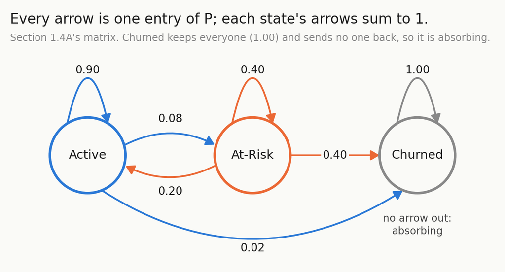

One arrow per non-zero entry of $P$. Churned has no arrow out — that is what absorbing means.

## State Vector Update

Current distribution: $\mathbf{v}_0 = [0.85, \; 0.10, \; 0.05]$

$$\mathbf{v}_{t+1} = \mathbf{v}_t \cdot P$$

**Month 1:**

$$\begin{aligned}
v_1(\text{Active}) &= 0.85(0.90) + 0.10(0.20) + 0.05(0.00) = 0.785 \\
v_1(\text{At-Risk}) &= 0.85(0.08) + 0.10(0.40) + 0.05(0.00) = 0.108 \\
v_1(\text{Churned}) &= 0.85(0.02) + 0.10(0.40) + 0.05(1.00) = 0.107
\end{aligned}$$

$\mathbf{v}_1 = [0.785, \; 0.108, \; 0.107]$

## Month 2 Iteration

$$\mathbf{v}_2 = \mathbf{v}_1 \cdot P$$

$$\begin{aligned}
v_2(\text{Active}) &= 0.785(0.90) + 0.108(0.20) + 0.107(0.00) = \mathbf{0.7281} \\
v_2(\text{At-Risk}) &= 0.785(0.08) + 0.108(0.40) + 0.107(0.00) = \mathbf{0.1060} \\
v_2(\text{Churned}) &= 0.785(0.02) + 0.108(0.40) + 0.107(1.00) = \mathbf{0.1659}
\end{aligned}$$

**Tip**

Sum check: $0.7281 + 0.1060 + 0.1659 = 1.000$ ✓

In 2 months: Active shrinks from 85% → 72.81%. Churned grows from 5% → 16.59%.

## Steady State

The long-run distribution where $\boldsymbol{\pi} \cdot P = \boldsymbol{\pi}$:

$$\boldsymbol{\pi} \cdot P = \boldsymbol{\pi}, \qquad \sum_i \pi_i = 1$$

With an absorbing state (Churned), the steady state is:

$$\boldsymbol{\pi}^* = [0, \; 0, \; 1]$$

**Warning**

**Critical insight:** Under current dynamics, ALL customers eventually churn.  
The steady-state characterises the long-run trajectory under current dynamics, not a normative target.  
Use steady-state to **motivate intervention** — not to describe a desirable outcome.

## Where the Distribution Goes

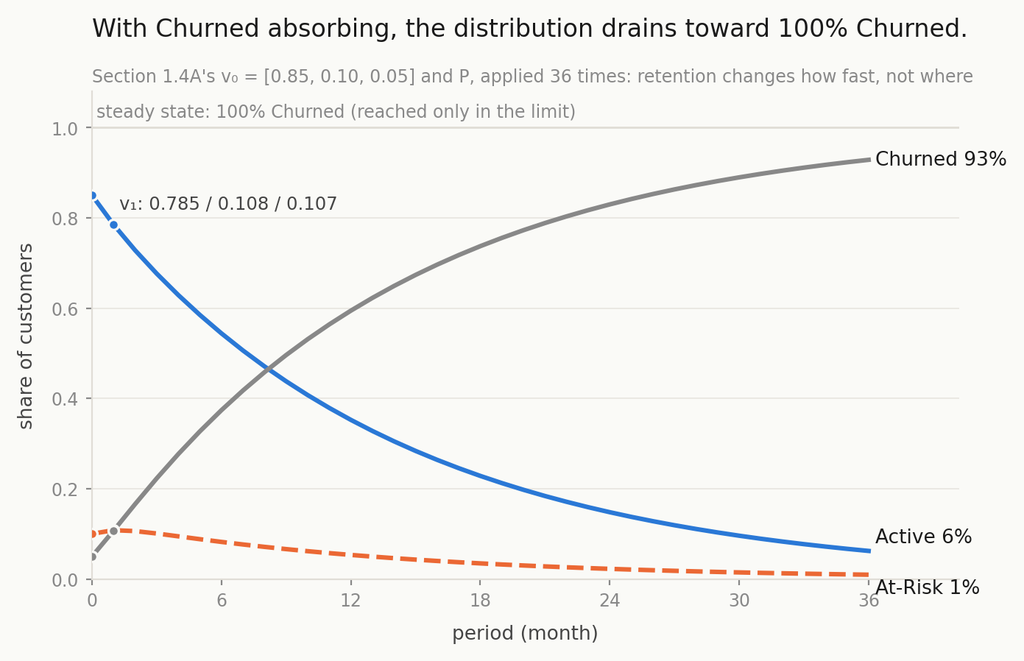

With Churned absorbing, the destination is fixed at 100% Churned; retention changes how fast you get there.

## Expected Time to Absorption

If the destination is always Churned, the only thing left to measure is **how long the journey takes**. Let $t_i$ = expected periods from state $i$ to absorption ($t_{\text{Churned}} = 0$).

**First-step analysis** — one period elapses, then you face $t_j$ from wherever you land:

$$t_i = 1 + \sum_{j \text{ transient}} P_{ij}\, t_j$$

$$t_A = 1 + 0.90\,t_A + 0.08\,t_R \;\Rightarrow\; 0.10\,t_A - 0.08\,t_R = 1$$
$$t_R = 1 + 0.20\,t_A + 0.40\,t_R \;\Rightarrow\; -0.20\,t_A + 0.60\,t_R = 1$$

$$t_A = \mathbf{15.5 \text{ months}}, \qquad t_R = \mathbf{6.8 \text{ months}}$$

**Tip**

Matrix form (what code returns): strip the absorbing row/column to get the transient block $Q$, then $\mathbf{t} = (I - Q)^{-1}\mathbf{1}$ — the **fundamental matrix** $N = (I-Q)^{-1}$, row-summed. Sanity check: all $t_i > 0$, and the healthier state has the larger $t_i$.

## Modeling an Intervention

What if a campaign improves the At-Risk → Active transition from 20% to 35%?

**New matrix $P'$:** row 2 is re-balanced — At-Risk $\to$ Active rises $0.20 \to 0.35$ and At-Risk $\to$ At-Risk falls $0.40 \to 0.25$, so the row still sums to 1.

**Tip**

Recompute $\mathbf{v}_1' = \mathbf{v}_0 \cdot P'$ and compare with $\mathbf{v}_1$.

The difference in Active share after 1 month **is the intervention effect** — directly comparable to a CLV-weighted dollar impact.

This is how Markov models inform retention campaign ROI.

## Scope and Limitations

**Estimands**

- $\mathbf{v}_{t+k}$: predicted state distribution $k$ periods ahead under current $P$
- Steady-state $\boldsymbol{\pi}^*$: long-run distribution if $P$ remains stationary
- $\Delta \mathbf{v}_1$: first-period distributional effect of an intervention on $P$

**Assumptions and limitations**

- **Markov property:** next state depends only on current state, not history
- **Stationarity:** $P$ is assumed constant over time
- Transition probabilities are estimated from data; standard errors on $\boldsymbol{\pi}^*$ are rarely reported in practice

## Checkpoint

1. Verify that row 2 of $P$ sums to 1.
2. Starting from $\mathbf{v}_0 = [0.45, 0.40, 0.15]$, compute $\mathbf{v}_1$.
3. What does it mean for Churned to be an absorbing state? Give a business interpretation.
4. The At-Risk → Active rate improves from 0.20 to 0.35. Without computing, in which direction does $\mathbf{v}_1$ change compared to the baseline?
5. A manager says “Our steady-state shows 100% churn — the model must be broken.” How do you respond?

Answers in the lecture notes, under “Slide Checkpoint Answers” (numbered to match this slide).